# week 6 homework

### Libraries

```python
import numpy as np
from scipy import stats
import pylab as pl
%matplotlib inline
from scipy import stats
```

### 1. Please construct a two-dimensional numpy array composed of random integers (in a range of -10 to 38) with a size of 5 columns (cities A, B, C, D, and E) and 364 rows (days).

```python
#np.random.seed(42)
A = np.random.randint(-10, 39, 364)
B = np.random.randint(-10, 39, 364)
C = np.random.randint(-10, 39, 364)
D = np.random.randint(-10, 39, 364)
E = np.random.randint(-10, 39, 364)


print(type(A))

year_ = [A, B, C, D, E]
print(type(year))




year = np.asarray(year_)

print(type(year))
print(year.shape)
print(year)


# year = A + B
#year = np.concatenate(A,np.concatenate(B,np.concatenate(C,np.concatenate(D,E))))
```

```
<class 'numpy.ndarray'>
<class 'numpy.ndarray'>
<class 'numpy.ndarray'>
(5, 364)
[[  0  12  15 ...,  23 -10  15]
 [ 32  -1  19 ...,   1  36  38]
 [ 31  27   7 ...,  15   1   6]
 [  3   3  23 ...,  13  23  11]
 [ -8   1  17 ...,   4  30  12]]
```

### 2. These are the measured temperatures and determine which of these 5 cities is the hottest one and which of these is the coldest one simply by your code. You should not decide these manually, in other words, your code should decide.

```python
# first way
A_avg_temp = np.mean(year[0,])
B_avg_temp = np.mean(year[1,])
C_avg_temp = np.mean(year[2,])
D_avg_temp = np.mean(year[3,])
E_avg_temp = np.mean(year[4,])

print(A_avg_temp)
print(B_avg_temp)
print(C_avg_temp)
print(D_avg_temp)
print(E_avg_temp)
```

```
13.9038461538
13.4807692308
13.4120879121
14.0384615385
14.9945054945
```

```python
city_name = ['A','B','C','D','E']
city_mean = []
city_median = []
city_mode = []

for i in range(5):
    city_mean.append(np.mean(year[i,]))
    city_median.append(np.median(year[i,]))


print(city_mean)
print(city_median)

max_city_mean = max(city_mean)
min_city_mean = min(city_mean)
max_city_median = max(city_median)
min_city_median = min(city_median)
max_city_name_mean = city_name[city_mean.index(max(city_mean))]
min_city_name_mean = city_name[city_mean.index(min(city_mean))]
max_city_name_median = city_name[city_median.index(max(city_median))]
min_city_name_median = city_name[city_median.index(min(city_median))]

#city_name[city_mean.index(min(city_mean))]

print("Hottest city is %s with average temp of %f"%(max_city_name_mean,max_city_mean))
print("Hottest city is %s with median temp of %f"%(max_city_name_median,max_city_median))
print("Coldest city is %s with average temp of %f"%(min_city_name_mean,min_city_mean))
print("Coldest city is %s with median temp of %f"%(min_city_name_median,min_city_median))
```

```
[13.903846153846153, 13.48076923076923, 13.412087912087912, 14.038461538461538, 14.994505494505495]
[14.0, 13.0, 13.0, 13.0, 15.0]
Hottest city is E with average temp of 14.994505
Hottest city is E with median temp of 15.000000
Coldest city is C with average temp of 13.412088
Coldest city is B with median temp of 13.000000
```

### 3. Figure out which is the hottest day (with a comparison through 5 cities) again by your Python code, please. Is it possible to look for a (statistically) significant difference? If so, how?

```python
year_transpose = np.transpose(year)

hottest_day = []


for i in range(364):
    hottest_day.append(np.mean(year_transpose[i,]))


max(hottest_day)
min(hottest_day)
which_day_hottest_day = hottest_day.index(max(hottest_day))
which_day_coldest_day = hottest_day.index(min(hottest_day))


print("Hottest day is %i with average temp of 5 cities %f"%(which_day_hottest_day,max(hottest_day)))
print("Coldest day is %i with average temp of 5 cities %f"%(which_day_coldest_day,min(hottest_day)))
```

```
Hottest day is 134 with average temp of 5 cities 30.800000
Coldest day is 39 with average temp of 5 cities -5.400000
```

```python
i = 0
j = 0
while(i < 5):
    j = 4
    while( j > i & j <= 4):
        print("between city %s and city %s t-test result:"%(city_name[i],city_name[j]))
        print(stats.ttest_ind(year[i,], year[j,]))
        j = j - 1
    i = i + 1
```

```
between city A and city E t-test result:
Ttest_indResult(statistic=-1.0451566963082197, pvalue=0.29629841385715144)
between city A and city D t-test result:
Ttest_indResult(statistic=-0.12892597280200968, pvalue=0.89745193224846076)
between city A and city C t-test result:
Ttest_indResult(statistic=0.48113747933284373, pvalue=0.63056376460673103)
between city A and city B t-test result:
Ttest_indResult(statistic=0.4007534382265201, pvalue=0.68871957118735994)
between city B and city E t-test result:
Ttest_indResult(statistic=-1.4265197091487123, pvalue=0.15414826427691888)
between city B and city D t-test result:
Ttest_indResult(statistic=-0.5252714057357567, pvalue=0.59955490817464008)
between city B and city C t-test result:
Ttest_indResult(statistic=0.066037169417255626, pvalue=0.94736641335068894)
between city C and city E t-test result:
Ttest_indResult(statistic=-1.5397843814226591, pvalue=0.12404863908441023)
between city C and city D t-test result:
Ttest_indResult(statistic=-0.60914130714110148, pvalue=0.54262134326920552)
between city D and city E t-test result:
Ttest_indResult(statistic=-0.91084349248299301, pvalue=0.36268015725985059)
```

### 4. Please find a way (among one of the python libraries) to visualize/demonstrate these 364 days with a figure as an average of 5 cities. Hint: There should be 364 x 5 data points.

```
City A :
```

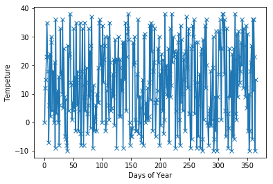

```
City B :
```

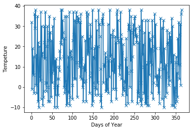

```
City C :
```

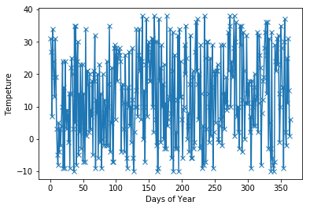

```
City D :
```

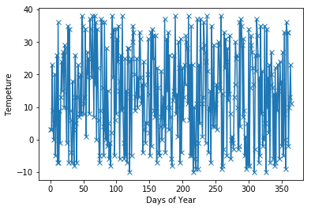

```
City E :
```

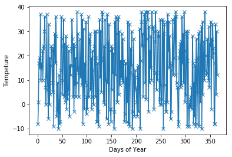

```
Average :
```

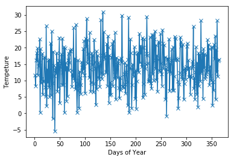

```python
day = np.linspace(1, 364, 364)
#print(day)
year_day = [day,A,B,C,D,E,hottest_day]
#print(year_day)
#year_transpose_avg = np.concatenate(year_transpose,hottest_day)
#print(year_transpose_avg.shape)

year_day = np.asarray(year_day)
#print(year.shape)
#print(year_day.shape)

i = 1
while(i <= 6):
    if(i== 6):
        print("Average :")
    else:
        print("City %s :"%(city_name[i-1]))
    pl.plot(np.array(year_day[0,]),np.array(year_day[i,]),
           'x-',label = 'Xsaved')
    pl.xlabel('Days of Year')
    pl.ylabel('Tempeture')
    pl.show()
    i = i + 1
```

### 5. Suppose that these 364 days are 52 weeks. Then please provide a weekly (average) illustration of these cities and illustrate them via figures/plots. Hint: there should be 52 x 5 data points.

```
City A :
```

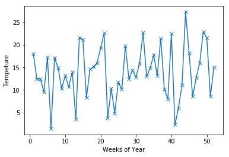

```
City B :
```

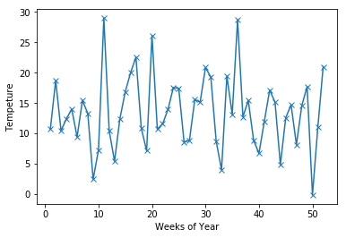

```
City C :
```

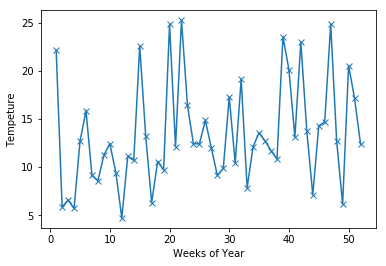

```
City D :
```

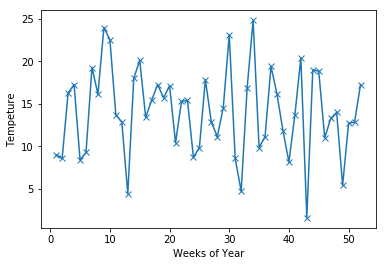

```
City E :
```

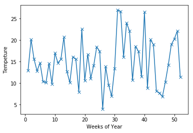

```
Average :
```

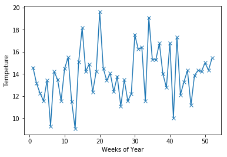

```python
week_A = []
week_B = []
week_C = []
week_D = []
week_E = []
week_Avg = []


i = 0
j = 0

while(i < 364):
    A_ = 0
    B_ = 0
    C_ = 0
    D_ = 0
    E_ = 0
    Avg_ = 0
    j = 0
    while(j < 7):
        A_ += A [i]
        B_ += B [i]
        C_ += C [i]
        D_ += D [i]
        E_ += E [i]
        Avg_ += hottest_day[i]
        j = j + 1
        i = i + 1
    week_A.append(A_/7)
    week_B.append(B_/7)
    week_C.append(C_/7)
    week_D.append(D_/7)
    week_E.append(E_/7)
    week_Avg.append(Avg_/7)

week = np.linspace(1, 52, 52)
year_week = [week,week_A,week_B,week_C,week_D,week_E,week_Avg]
year_week = np.asarray(year_week)

i = 1
while(i <= 6):
    if(i== 6):
        print("Average :")
    else:
        print("City %s :"%(city_name[i-1]))
    pl.plot(np.array(year_week[0,]),np.array(year_week[i,]),
           'x-',label = 'Xsaved')
    pl.xlabel('Weeks of Year')
    pl.ylabel('Tempeture')
    pl.show()
    i = i + 1
```